# Exploratory Data Analysis on Udemy Courses

### About this Data

Udemy is a massive online open course (MOOC) platform that offers both free and paid courses. Anybody can create a course, a business model by which allowed Udemy to have hundreds of thousands of courses.

This data has the following column names(explanation attached).

- `course_id` - Course ID
- `course_title` - Course Title
- `url` - Course URL
- `is_paid` - Whether the course is free or paid
- `price` - Course Price
- `num_subscribers` - Number of subscribers
- `num_reviews` - Number of reviews
- `num_lectures` - Number of lectures
- `level` - Course difficulty
- `content_duration` - Duration of all course materials
- `published_timestamp` - Date that the course was published.
- `Subject` - Course subject

#### Importing the necessary packages

```python
import pandas as pd
import numpy as np
import seaborn as sns
import matplotlib.pyplot as plt
```

#### Load dataset into dataframe

```python
df = pd.read_csv('./udemy_courses.csv')
```

#### Quick view of the data

```python
df.head()
```

|  | course_id | course_title | url | is_paid | price | num_subscribers | num_reviews | num_lectures | level | content_duration | published_timestamp | subject |
| --- | --- | --- | --- | --- | --- | --- | --- | --- | --- | --- | --- | --- |
| 0 | 1070968 | Ultimate Investment Banking Course | https://www.udemy.com/ultimate-investment-bank... | True | 200 | 2147 | 23 | 51 | All Levels | 1.5 | 2017-01-18T20:58:58Z | Business Finance |
| 1 | 1113822 | Complete GST Course & Certification - Grow You... | https://www.udemy.com/goods-and-services-tax/ | True | 75 | 2792 | 923 | 274 | All Levels | 39.0 | 2017-03-09T16:34:20Z | Business Finance |
| 2 | 1006314 | Financial Modeling for Business Analysts and C... | https://www.udemy.com/financial-modeling-for-b... | True | 45 | 2174 | 74 | 51 | Intermediate Level | 2.5 | 2016-12-19T19:26:30Z | Business Finance |
| 3 | 1210588 | Beginner to Pro - Financial Analysis in Excel ... | https://www.udemy.com/complete-excel-finance-c... | True | 95 | 2451 | 11 | 36 | All Levels | 3.0 | 2017-05-30T20:07:24Z | Business Finance |
| 4 | 1011058 | How To Maximize Your Profits Trading Options | https://www.udemy.com/how-to-maximize-your-pro... | True | 200 | 1276 | 45 | 26 | Intermediate Level | 2.0 | 2016-12-13T14:57:18Z | Business Finance |

#### Summary of dataset

```python
df.info()
```

```
<class 'pandas.core.frame.DataFrame'>
RangeIndex: 3678 entries, 0 to 3677
Data columns (total 12 columns):
 #   Column               Non-Null Count  Dtype
---  ------               --------------  -----
 0   course_id            3678 non-null   int64
 1   course_title         3678 non-null   object
 2   url                  3678 non-null   object
 3   is_paid              3678 non-null   bool
 4   price                3678 non-null   int64
 5   num_subscribers      3678 non-null   int64
 6   num_reviews          3678 non-null   int64
 7   num_lectures         3678 non-null   int64
 8   level                3678 non-null   object
 9   content_duration     3678 non-null   float64
 10  published_timestamp  3678 non-null   object
 11  subject              3678 non-null   object
dtypes: bool(1), float64(1), int64(5), object(5)
memory usage: 319.8+ KB
```

#### Summary Statistics of dataset

```python
df.describe()
```

|  | course_id | price | num_subscribers | num_reviews | num_lectures | content_duration |
| --- | --- | --- | --- | --- | --- | --- |
| count | 3.678000e+03 | 3678.000000 | 3678.000000 | 3678.000000 | 3678.000000 | 3678.000000 |
| mean | 6.759720e+05 | 66.049483 | 3197.150625 | 156.259108 | 40.108755 | 4.094517 |
| std | 3.432732e+05 | 61.005755 | 9504.117010 | 935.452044 | 50.383346 | 6.053840 |
| min | 8.324000e+03 | 0.000000 | 0.000000 | 0.000000 | 0.000000 | 0.000000 |
| 25% | 4.076925e+05 | 20.000000 | 111.000000 | 4.000000 | 15.000000 | 1.000000 |
| 50% | 6.879170e+05 | 45.000000 | 911.500000 | 18.000000 | 25.000000 | 2.000000 |
| 75% | 9.613555e+05 | 95.000000 | 2546.000000 | 67.000000 | 45.750000 | 4.500000 |
| max | 1.282064e+06 | 200.000000 | 268923.000000 | 27445.000000 | 779.000000 | 78.500000 |

#### Finding Duplicates in dataset.

```python
df[df.duplicated()]
```

|  | course_id | course_title | url | is_paid | price | num_subscribers | num_reviews | num_lectures | level | content_duration | published_timestamp | subject |
| --- | --- | --- | --- | --- | --- | --- | --- | --- | --- | --- | --- | --- |
| 787 | 837322 | Essentials of money value: Get a financial Life ! | https://www.udemy.com/essentials-of-money-value/ | True | 20 | 0 | 0 | 20 | All Levels | 0.616667 | 2016-05-16T18:28:30Z | Business Finance |
| 788 | 1157298 | Introduction to Forex Trading Business For Beg... | https://www.udemy.com/introduction-to-forex-tr... | True | 20 | 0 | 0 | 27 | Beginner Level | 1.500000 | 2017-04-23T16:19:01Z | Business Finance |
| 894 | 1035638 | Understanding Financial Statements | https://www.udemy.com/understanding-financial-... | True | 25 | 0 | 0 | 10 | All Levels | 1.000000 | 2016-12-15T14:56:17Z | Business Finance |
| 1100 | 1084454 | CFA Level 2- Quantitative Methods | https://www.udemy.com/cfa-level-2-quantitative... | True | 40 | 0 | 0 | 35 | All Levels | 5.500000 | 2017-07-02T14:29:35Z | Business Finance |
| 1473 | 185526 | MicroStation - Células | https://www.udemy.com/microstation-celulas/ | True | 20 | 0 | 0 | 9 | Beginner Level | 0.616667 | 2014-04-15T21:48:55Z | Graphic Design |
| 2561 | 28295 | Learn Web Designing & HTML5/CSS3 Essentials in... | https://www.udemy.com/build-beautiful-html5-we... | True | 75 | 43285 | 525 | 24 | All Levels | 4.000000 | 2013-01-03T00:55:31Z | Web Development |

#### View the distinct Difficulty Levels

```python
df.level.unique()
```

```
array(['All Levels', 'Intermediate Level', 'Beginner Level',
       'Expert Level'], dtype=object)
```

#### View the distinct subjects.

```python
df.subject.unique()
```

```
array(['Business Finance', 'Graphic Design', 'Musical Instruments',
       'Web Development'], dtype=object)
```

#### View Paid or Free status

```python
df.is_paid.unique()
```

```
array([ True, False])
```

#### Paid courses with prices less than or equal to 0.

#### Courses that are Paid should Not have a Price less than or equal to 0

```python
df[(df.is_paid) & (df.price <= 0)]
```

|  | course_id | course_title | url | is_paid | price | num_subscribers | num_reviews | num_lectures | level | content_duration | published_timestamp | subject |
| --- | --- | --- | --- | --- | --- | --- | --- | --- | --- | --- | --- | --- |

### Data Cleaning

1. Duplicates in dataset.
2. Erroneous datatypes
- `level` changed to an `ordered category`
- `subject changed` to `category`
- `published_timestamp` changed to `datetime`

#### Create a copy of the original dataframe before cleaning.

```python
df_clean = df.copy()
```

#### Remove duplicates

```python
df_clean = df_clean[~df_clean.duplicated()]
```

#### Confirm duplicates removal

```python
df_clean[df_clean.duplicated()]
```

|  | course_id | course_title | url | is_paid | price | num_subscribers | num_reviews | num_lectures | level | content_duration | published_timestamp | subject |
| --- | --- | --- | --- | --- | --- | --- | --- | --- | --- | --- | --- | --- |

#### Change datatypes

```python
df_clean.subject = df_clean.subject.astype('category')
df_clean.published_timestamp = pd.to_datetime(df_clean.published_timestamp)
ordered_levels = pd.api.types.CategoricalDtype(ordered=True, categories=['Beginner Level', 'Intermediate Level', 'Expert Level', 'All Levels'])
df_clean.level = df_clean.level.astype(ordered_levels)
```

#### Confirm data type changes

```python
df_clean.info()
```

```
<class 'pandas.core.frame.DataFrame'>
Int64Index: 3672 entries, 0 to 3677
Data columns (total 12 columns):
 #   Column               Non-Null Count  Dtype
---  ------               --------------  -----
 0   course_id            3672 non-null   int64
 1   course_title         3672 non-null   object
 2   url                  3672 non-null   object
 3   is_paid              3672 non-null   bool
 4   price                3672 non-null   int64
 5   num_subscribers      3672 non-null   int64
 6   num_reviews          3672 non-null   int64
 7   num_lectures         3672 non-null   int64
 8   level                3672 non-null   category
 9   content_duration     3672 non-null   float64
 10  published_timestamp  3672 non-null   datetime64[ns, UTC]
 11  subject              3672 non-null   category
dtypes: bool(1), category(2), datetime64[ns, UTC](1), float64(1), int64(5), object(2)
memory usage: 298.0+ KB
```

#### View timestamp data

```python
df_clean.published_timestamp.head()
```

```
0   2017-01-18 20:58:58+00:00
1   2017-03-09 16:34:20+00:00
2   2016-12-19 19:26:30+00:00
3   2017-05-30 20:07:24+00:00
4   2016-12-13 14:57:18+00:00
Name: published_timestamp, dtype: datetime64[ns, UTC]
```

#### View various subjects

```python
df_clean.subject.unique()
```

```
[Business Finance, Graphic Design, Musical Instruments, Web Development]
Categories (4, object): [Business Finance, Graphic Design, Musical Instruments, Web Development]
```

#### View the various levels

```python
df_clean.level.unique()
```

```
[All Levels, Intermediate Level, Beginner Level, Expert Level]
Categories (4, object): [Beginner Level < Intermediate Level < Expert Level < All Levels]
```

# Analysis and Visualizations

#### Distribution of Prices

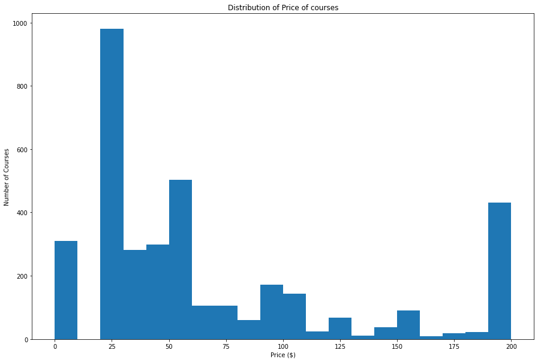

```python
plt.figure(figsize=(15,10))
bins = np.arange(df_clean['price'].min(), df_clean['price'].max()+10, 10)
plt.hist(df_clean['price'],bins=bins)
plt.xlabel('Price ($)')
plt.ylabel('Number of Courses')
plt.title('Distribution of Price of courses')
plt.show();
```

#### Distribution of Number of Subscribers

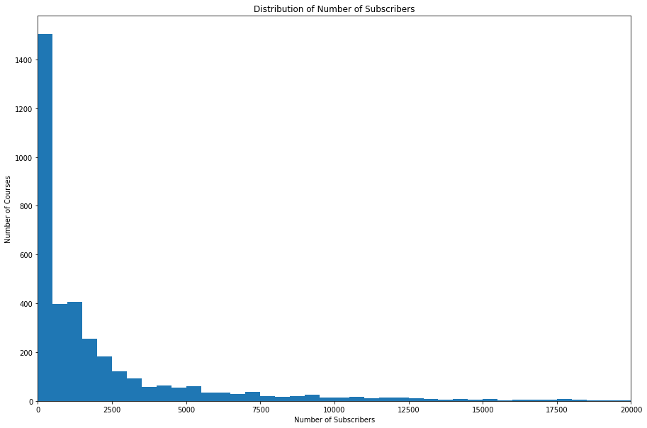

```python
plt.figure(figsize=(15,10))
bins = np.arange(df_clean['num_subscribers'].min(), df_clean['num_subscribers'].max()+500, 500)
plt.hist(df_clean['num_subscribers'],bins=bins)
plt.xlabel('Number of Subscribers')
plt.ylabel('Number of Courses')
plt.title('Distribution of Number of Subscribers')
plt.xlim(0,20000)
plt.show();
```

```python
paid_and_free_courses = df_clean.is_paid.value_counts().reset_index(name="number")
print(paid_and_free_courses)
```

```
   index  number
0   True    3362
1  False     310
```

#### Distribution of paid and free udemy courses

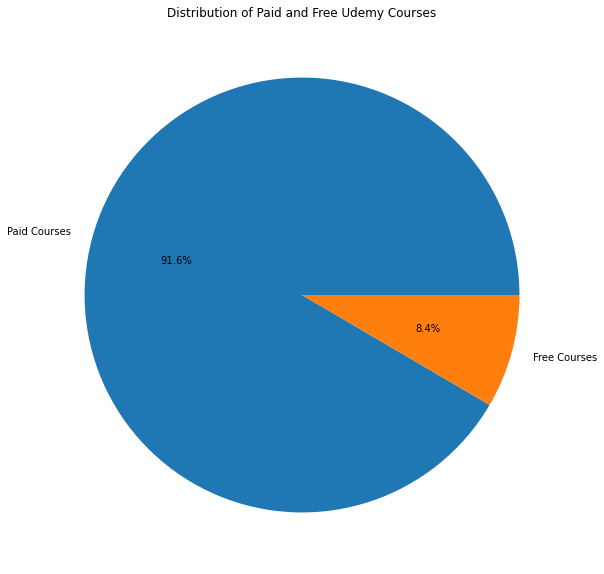

```python
# Get the number of paid and free courses
paid_and_free_courses = df_clean.is_paid.value_counts().reset_index(name="number")

# Display plot
labels = ['Paid Courses', 'Free Courses']
plt.figure(figsize=(10,10))
plt.pie(paid_and_free_courses['number'], labels=labels, autopct='%1.1f%%')
plt.title('Distribution of Paid and Free Udemy Courses')
plt.show()
```

#### The number of courses per subject.

```python
df_clean.subject.value_counts().reset_index(name='total_number')
```

|  | index | total_number |
| --- | --- | --- |
| 0 | Web Development | 1199 |
| 1 | Business Finance | 1191 |
| 2 | Musical Instruments | 680 |
| 3 | Graphic Design | 602 |

#### A plot showing the number of Courses Per Subject.

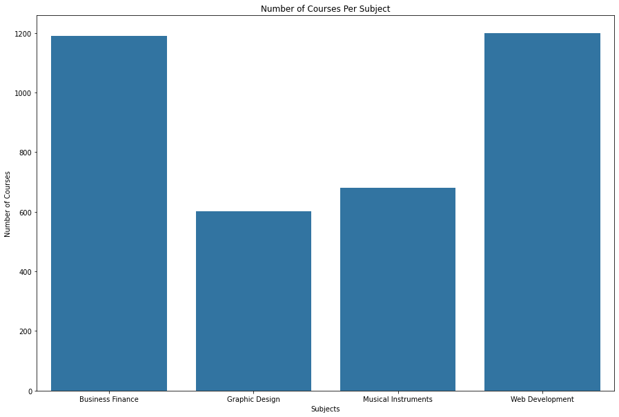

```python
# Set default color to be used by seaborn
default_color = sns.color_palette()[0]

# Bar Graph of Subject Distribution
plt.figure(figsize=(15,10))
sns.countplot(data= df_clean, x='subject', color=default_color)
plt.title('Number of Courses Per Subject')
plt.xlabel('Subjects')
plt.ylabel('Number of Courses');
```

#### Number of Courses Per Difficulty Level

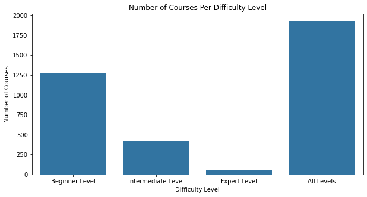

```python
plt.figure(figsize=(10,5))
sns.countplot(data= df_clean, x='level', color=default_color)
plt.title('Number of Courses Per Difficulty Level')
plt.xlabel('Difficulty Level')
plt.ylabel('Number of Courses');
```

#### Examine the Course Difficulty Levels Across the Various Subjects

```python
df_clean.groupby(['subject','level']).size()
```

```
subject              level
Business Finance     Beginner Level        339
                     Intermediate Level    128
                     Expert Level           31
                     All Levels            693
Graphic Design       Beginner Level        242
                     Intermediate Level     57
                     Expert Level            5
                     All Levels            298
Musical Instruments  Beginner Level        296
                     Intermediate Level    101
                     Expert Level            7
                     All Levels            276
Web Development      Beginner Level        391
                     Intermediate Level    135
                     Expert Level           15
                     All Levels            658
dtype: int64
```

#### Plot Distribution of difficulty level per Subject

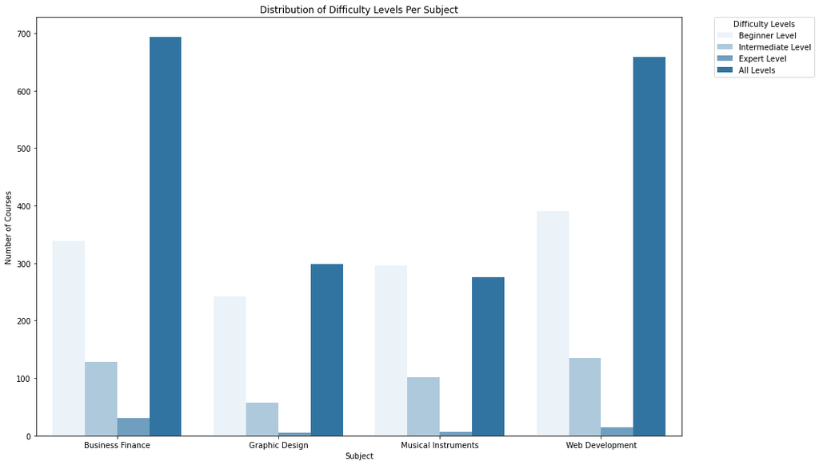

```python
plt.figure(figsize=(15,10))
ax = sns.countplot(data=df_clean, x='subject', hue='level', color=default_color);
plt.legend(bbox_to_anchor=(1.05, 1), loc=2, borderaxespad=0., title='Difficulty Levels')
plt.title('Distribution of Difficulty Levels Per Subject');
plt.xlabel('Subject')
plt.ylabel('Number of Courses');
```

#### Compare Difficulty Level and Price for Paid Courses

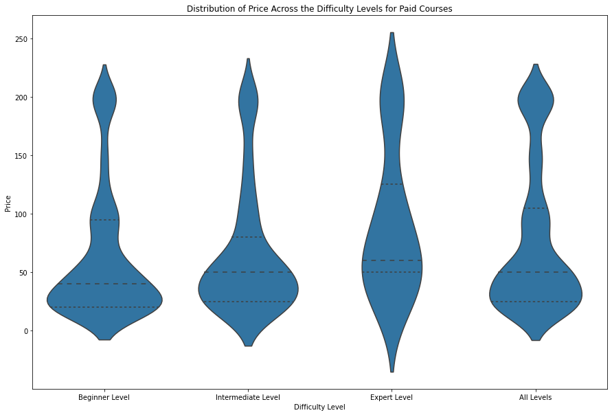

```python
paid_courses = df_clean[df_clean.is_paid]
plt.figure(figsize=(15,10))
sns.violinplot(data=paid_courses, x='level', y='price',
               inner="quartile", color=default_color);
plt.title('Distribution of Price Across the Difficulty Levels for Paid Courses')
plt.xlabel('Difficulty Level')
plt.ylabel('Price');

# The median Price for the courses increase from Beginner to Expert Level.
# For the 'All Levels', the median price is almost the same as the Intermediate
# Level.
```

#### Compare Difficulty Level and Duration for Paid Courses

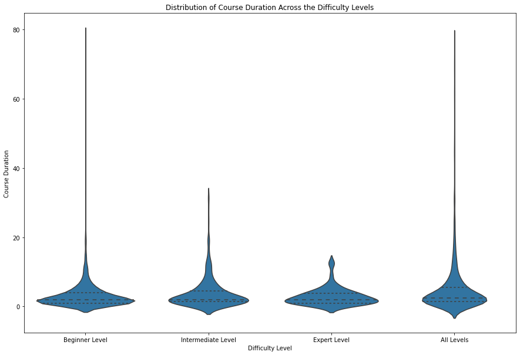

```python
plt.figure(figsize=(15,10))
sns.violinplot(data=paid_courses, x='level', y='content_duration',
              inner="quartile", color=default_color);
plt.title('Distribution of Course Duration Across the Difficulty Levels')
plt.xlabel('Difficulty Level')
plt.ylabel('Course Duration');

# The median Course Duration across the Difficulty Levels almost the same.
# We observe that the number of courses reduce from Beginner to Expert Level.
```

#### Create Year and Month Columns to Evaluate Prices and Subscriptions Across Year and Months

```python
df_clean['year'] = df_clean.published_timestamp.dt.year
df_clean['month'] = df_clean.published_timestamp.dt.month_name()

# preview data after adding additional columns
df_clean.head()
```

|  | course_id | course_title | url | is_paid | price | num_subscribers | num_reviews | num_lectures | level | content_duration | published_timestamp | subject | year | month |
| --- | --- | --- | --- | --- | --- | --- | --- | --- | --- | --- | --- | --- | --- | --- |
| 0 | 1070968 | Ultimate Investment Banking Course | https://www.udemy.com/ultimate-investment-bank... | True | 200 | 2147 | 23 | 51 | All Levels | 1.5 | 2017-01-18 20:58:58+00:00 | Business Finance | 2017 | January |
| 1 | 1113822 | Complete GST Course & Certification - Grow You... | https://www.udemy.com/goods-and-services-tax/ | True | 75 | 2792 | 923 | 274 | All Levels | 39.0 | 2017-03-09 16:34:20+00:00 | Business Finance | 2017 | March |
| 2 | 1006314 | Financial Modeling for Business Analysts and C... | https://www.udemy.com/financial-modeling-for-b... | True | 45 | 2174 | 74 | 51 | Intermediate Level | 2.5 | 2016-12-19 19:26:30+00:00 | Business Finance | 2016 | December |
| 3 | 1210588 | Beginner to Pro - Financial Analysis in Excel ... | https://www.udemy.com/complete-excel-finance-c... | True | 95 | 2451 | 11 | 36 | All Levels | 3.0 | 2017-05-30 20:07:24+00:00 | Business Finance | 2017 | May |
| 4 | 1011058 | How To Maximize Your Profits Trading Options | https://www.udemy.com/how-to-maximize-your-pro... | True | 200 | 1276 | 45 | 26 | Intermediate Level | 2.0 | 2016-12-13 14:57:18+00:00 | Business Finance | 2016 | December |

#### View summary information about dataframe

```python
df_clean.info()
```

```
<class 'pandas.core.frame.DataFrame'>
Int64Index: 3672 entries, 0 to 3677
Data columns (total 14 columns):
 #   Column               Non-Null Count  Dtype
---  ------               --------------  -----
 0   course_id            3672 non-null   int64
 1   course_title         3672 non-null   object
 2   url                  3672 non-null   object
 3   is_paid              3672 non-null   bool
 4   price                3672 non-null   int64
 5   num_subscribers      3672 non-null   int64
 6   num_reviews          3672 non-null   int64
 7   num_lectures         3672 non-null   int64
 8   level                3672 non-null   category
 9   content_duration     3672 non-null   float64
 10  published_timestamp  3672 non-null   datetime64[ns, UTC]
 11  subject              3672 non-null   category
 12  year                 3672 non-null   int64
 13  month                3672 non-null   object
dtypes: bool(1), category(2), datetime64[ns, UTC](1), float64(1), int64(6), object(3)
memory usage: 515.4+ KB
```

#### Plot of the number of courses per Year Published

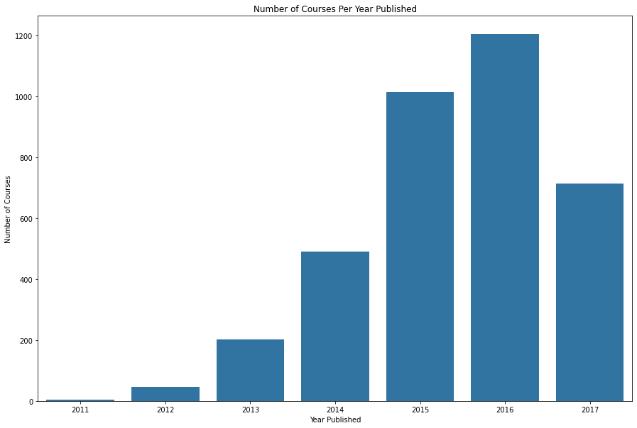

```python
plt.figure(figsize=(15,10))
sns.countplot(data=df_clean, x='year', color=default_color);
plt.title('Number of Courses Per Year Published')
plt.xlabel('Year Published')
plt.ylabel('Number of Courses');
```

#### Plot of the number of courses Per Month Published

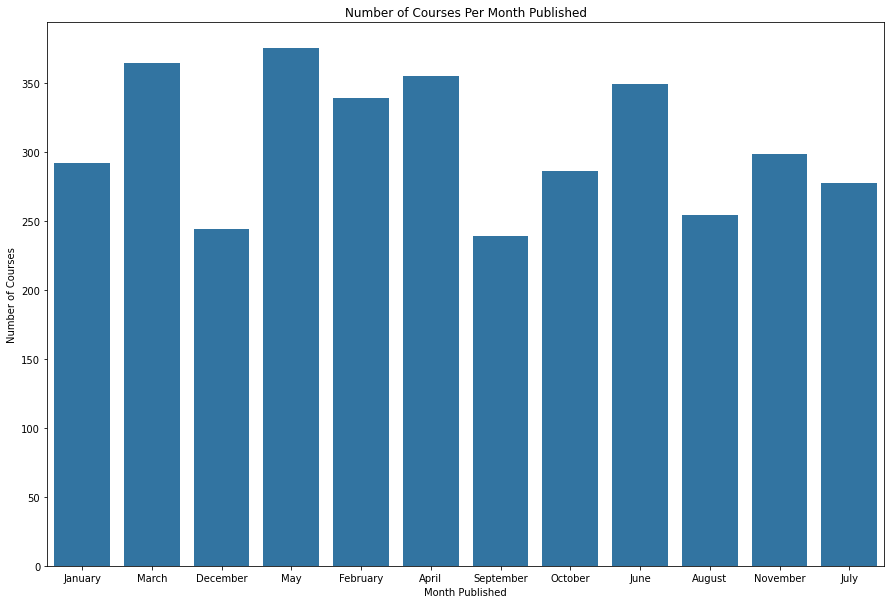

```python
plt.figure(figsize=(15,10))
sns.countplot(data=df_clean, x='month', color=default_color);
plt.title('Number of Courses Per Month Published')
plt.xlabel('Month Published')
plt.ylabel('Number of Courses');
```

#### Course with the highest Number of subscribers

```python
df_clean[df_clean.num_subscribers == df_clean.num_subscribers.max()]
```

|  | course_id | course_title | url | is_paid | price | num_subscribers | num_reviews | num_lectures | level | content_duration | published_timestamp | subject | year | month |
| --- | --- | --- | --- | --- | --- | --- | --- | --- | --- | --- | --- | --- | --- | --- |
| 2827 | 41295 | Learn HTML5 Programming From Scratch | https://www.udemy.com/learn-html5-programming-... | False | 0 | 268923 | 8629 | 45 | All Levels | 10.5 | 2013-02-14 07:03:41+00:00 | Web Development | 2013 | February |

#### Course(s) with the Least Number of subscribers

```python
df_clean[df_clean.num_subscribers == df_clean.num_subscribers.min()]
```

|  | course_id | course_title | url | is_paid | price | num_subscribers | num_reviews | num_lectures | level | content_duration | published_timestamp | subject | year | month |
| --- | --- | --- | --- | --- | --- | --- | --- | --- | --- | --- | --- | --- | --- | --- |
| 453 | 837322 | Essentials of money value: Get a financial Life ! | https://www.udemy.com/essentials-of-money-value/ | True | 20 | 0 | 0 | 20 | All Levels | 0.616667 | 2016-05-16 18:28:30+00:00 | Business Finance | 2016 | May |
| 454 | 1157298 | Introduction to Forex Trading Business For Beg... | https://www.udemy.com/introduction-to-forex-tr... | True | 20 | 0 | 0 | 27 | Beginner Level | 1.500000 | 2017-04-23 16:19:01+00:00 | Business Finance | 2017 | April |
| 455 | 1282064 | Cryptocurrency (BTC & ETH) Investment & Tradin... | https://www.udemy.com/cryptocurrency-btc-eth-i... | True | 20 | 0 | 0 | 7 | Beginner Level | 2.500000 | 2017-07-06 21:46:30+00:00 | Business Finance | 2017 | July |
| 456 | 1247992 | Introduction to Project Management for Finance... | https://www.udemy.com/introduction-to-project-... | True | 50 | 0 | 0 | 9 | Beginner Level | 2.000000 | 2017-07-03 21:40:32+00:00 | Business Finance | 2017 | July |
| 457 | 1251582 | Best Practices in Corporate Budgeting | https://www.udemy.com/best-practices-corporate... | True | 50 | 0 | 0 | 9 | Intermediate Level | 2.000000 | 2017-06-29 22:01:56+00:00 | Business Finance | 2017 | June |
| ... | ... | ... | ... | ... | ... | ... | ... | ... | ... | ... | ... | ... | ... | ... |
| 2402 | 1214670 | Tune that Sour Note on Your Piano | https://www.udemy.com/how-to-tune-your-own-piano/ | True | 20 | 0 | 0 | 6 | All Levels | 0.550000 | 2017-06-20 21:46:40+00:00 | Musical Instruments | 2017 | June |
| 2403 | 1272282 | Learn Vikings Soundtracks on the Piano by Ear | https://www.udemy.com/learn-vikings-soundtrack... | True | 20 | 0 | 0 | 8 | All Levels | 0.583333 | 2017-06-29 15:10:58+00:00 | Musical Instruments | 2017 | June |
| 2404 | 1224186 | Learn to Play Piano Like a Pro - Easy Piano Co... | https://www.udemy.com/learn-to-play-piano-like... | True | 35 | 0 | 0 | 13 | Beginner Level | 0.516667 | 2017-05-30 00:19:02+00:00 | Musical Instruments | 2017 | May |
| 2405 | 1265814 | ABRSM Grade III Piano Class - Handel Sonatina ... | https://www.udemy.com/abrsm-grade-iii-piano-cl... | True | 20 | 0 | 0 | 5 | Beginner Level | 0.516667 | 2017-07-06 16:12:34+00:00 | Musical Instruments | 2017 | July |
| 2418 | 1216340 | Learn to Play Sweet Child of Mine | https://www.udemy.com/learn-to-play-sweet-chil... | True | 20 | 0 | 0 | 23 | Intermediate Level | 1.500000 | 2017-06-30 17:33:29+00:00 | Musical Instruments | 2017 | June |

65 rows × 14 columns

#### Compare Price and Number of Subscribers

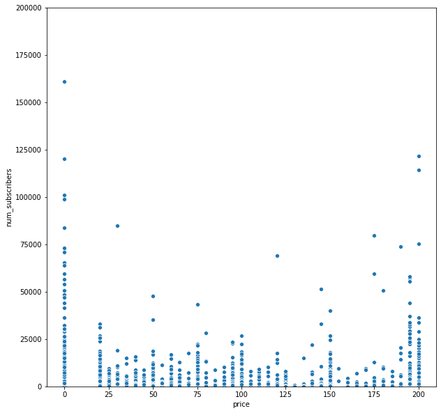

```python
plt.figure(figsize=(10,10))
sns.scatterplot(data=df_clean, x='price', y='num_subscribers');
plt.ylim(0,200000);

# No clear correlation between the price and the number of subscribers.
# It appears the Price doesn't determine the number of subscribers
# However the Free ie. Price = 0, courses had most subscribers.
```

```python
# Get the Individual Subjects and Plot the Monthly Mean for Price and Number of Subscribers

def monthly_mean(col_value):
  mean_df = df_clean[df_clean.subject == col_value]
  mean_df = mean_df.set_index('published_timestamp')
  return mean_df[['price', 'num_subscribers']].resample('M').mean()
```

```python
# Monthy Mean for Business Finance
bus_fin_mthly_mean = monthly_mean('Business Finance')

# Monthly Mean for Graphic Design
graph_des_mthly_mean = monthly_mean('Graphic Design')

# Monthly Mean for Musical Instruments
mus_inst_mthly_mean = monthly_mean('Musical Instruments')

# Monthly Mean for Web Development
web_dev_mthly_mean = monthly_mean('Web Development')
```

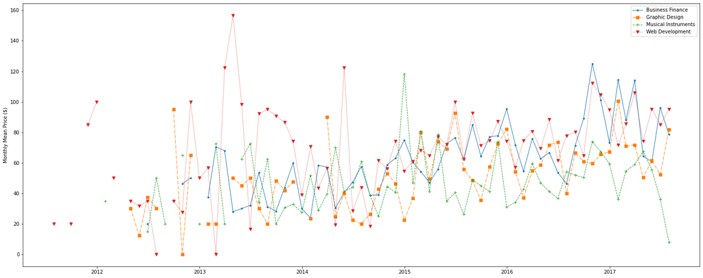

```python
# Plot Monthly Means for Price Across the Years
x_axis_vals = [2011, 2012, 2013, 2014, 2015, 2017, 2017]
xi = list(range(len(x_axis_vals)))

fig, ax = plt.subplots(figsize=(25,10))
ax.plot(bus_fin_mthly_mean['price'],
marker='.', linestyle='-', linewidth=1, label='Business Finance')
ax.plot(graph_des_mthly_mean['price'],
marker='s',linestyle='-.', linewidth=1, label='Graphic Design')
ax.plot(mus_inst_mthly_mean['price'],
marker='+', linestyle='--', linewidth=1, label='Musical Instruments')
ax.plot(web_dev_mthly_mean['price'],
marker='v',linestyle=':', linewidth=1, label='Web Development')
ax.set_ylabel('Monthly Mean Price ($)')
ax.legend();
# plt.xticks(xi, x_axis_vals);
```

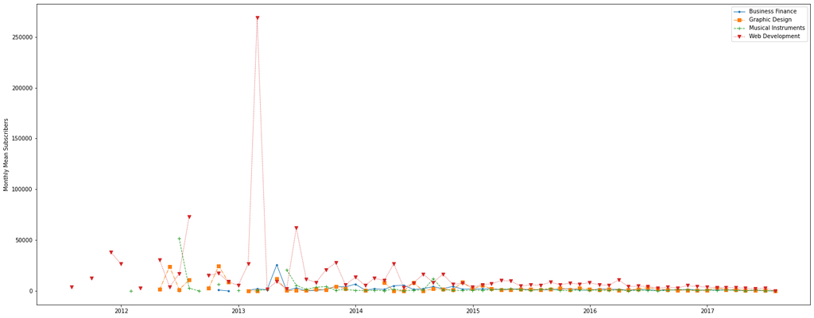

```python
# Plot Monthly Means for Number of Subscribers Across the Years
x_axis_vals = [2011, 2012, 2013, 2014, 2015, 2017, 2017]
xi = list(range(len(x_axis_vals)))

fig, ax = plt.subplots(figsize=(25,10))
ax.plot(bus_fin_mthly_mean['num_subscribers'],
marker='.', linestyle='-', linewidth=1, label='Business Finance')
ax.plot(graph_des_mthly_mean['num_subscribers'],
marker='s',linestyle='-.', linewidth=1, label='Graphic Design')
ax.plot(mus_inst_mthly_mean['num_subscribers'],
marker='+', linestyle='--', linewidth=1, label='Musical Instruments')
ax.plot(web_dev_mthly_mean['num_subscribers'],
marker='v',linestyle=':', linewidth=1, label='Web Development')
ax.set_ylabel('Monthly Mean Subscribers')
ax.legend();
# plt.xticks(xi, x_axis_vals);
```